# Sensitivity with ODEs

# Dynamic models

- models that have feedbacks (conditions evolve through time)
- numerical integration - usually done with a solver
  - only one independent variable ordinary differential equation (e.g just time)
  - we can use the ODE solver
  - derivative is first order (e.g $dy/dt$ = ; not $d^2y/dt$+dy/dy = f(y,t))
  - there are ways to solve high order and partial differential equations

# Sensitivity Analysis of a Differential Equation

We can apply sensitivity analysis to a differential equation

A key issue where is sensitivity of what?

Dynamic models often give you many many outputs - time series (streamflow every day for a year, population for 30 years) - or output over space (spatially averaged concentration after 10 days?)

So if we are asking ‘sensitivity of what’ we need to summarize results in some way (reduce their dimensionality )

Ideas?

# Some options for reducing output dimensionality (summarizing output)

Depends on what is important for your model application

- max
- mean
- min
- total
- variation
- time it takes for something to happen

So a key step in sensitivity analysis with a dynamics model is summarizing results into a few key measures

Its useful to turn that summarizing workflow into a function

# Workflow

- implement (or identify pre-existing) dynamic model
- obtain parameter sets (from sobel or LHS)
- build a function that will extract the information (metrics) you want from your dynamic model (output of the ode)
- create a data structure to store the metrics for each parameter set - in my example I call it metrics (but could be anything)
- decide on initial conditions and time period over which you will run the model
- run ODE for each parameter sets to fill in this metrics data structure
  - its usually helpful to create a wrapper function * runs ODE * extracts metrics
  - run wrapper function for each parameter sets
- send the metrics data structure back to the sensitivity analysis object (from sobel or LHS)
- plot and analyze results

# Example with our population ODE

Lets first generate parameter sets and figure out how to run with *1* of those parameter sets

Always a good practice to “try” you model on one parameter set *before* trying to run for all parameters

```r
source("../R/dpopgrowth.R")

dpopgrowth
```

```
## function (Time, P, parms)
## {
##     dP = parms$r * P * (1 - P/parms$K)
##     return(list(dP))
## }
```

```r
# lets start with sobel
library(sensitivity)

# come up with first set of sample parameters
# we will assume that we know the initial population,

Pinitial=10

# want to learn about sensitivity to growth rate (r) and carrying capacity
# set the number of parameters
np=2000
K = rnorm(mean=200, sd=50, n=np)
r = rnorm(mean=0.05, sd=0.01, n=np)
X1 = cbind.data.frame(r=r, K=K)

# repeat to get our second set of samples
K = rnorm(mean=200, sd=50, n=np)
r = rnorm(mean=0.05, sd=0.01, n=np)
X2 = cbind.data.frame(r=r, K=K)

# fix any negative values and they are not meaningful
X1 = X1 %>% map_df(pmax, 0.0)
X2 = X2 %>% map_df(pmax, 0.0)

# create our sobel object and get sets ofparameters for running the model

sens_P = sobolSalt(model = NULL,X1, X2, nboot = 300)

# our parameter sets are
head(sens_P$X)
```

```
##            [,1]     [,2]
## [1,] 0.05014119 260.4940
## [2,] 0.05511826 227.5640
## [3,] 0.04702878 181.2691
## [4,] 0.05684321 150.2398
## [5,] 0.05854149 269.2174
## [6,] 0.06019101 235.1154
```

```r
# lets add names
colnames(sens_P$X) = c("r","K")

head(sens_P$X)
```

```
##               r        K
## [1,] 0.05014119 260.4940
## [2,] 0.05511826 227.5640
## [3,] 0.04702878 181.2691
## [4,] 0.05684321 150.2398
## [5,] 0.05854149 269.2174
## [6,] 0.06019101 235.1154
```

# Running the ODE and summarizing output

- run our differential equation and keep the output

BUT what output do we want to keep?

A couple of options

- how about maximum population if we run the model for 200 years,
- how many years to get to the carrying capacity
- how many year to get to some pre-determined threshold

For illustration lets look at running just one parameter sets and summarizing results

```r
sens_P$X[1,]
```

```
##            r            K
##   0.05014119 260.49395433
```

```r
# recall ODE needs ALL of our parameters in a single list
# initial population and times for which we want output
Pinitial
```

```
## [1] 10
```

```r
# gets results for 200 years (evaluating every year)
simtimes = seq(from=1, to=200)
parms = list(r=sens_P$X[1,"r"], K=sens_P$X[1,"K"])

# or
parms = list(r=as.data.frame(sens_P$X)$r[1], K=as.data.frame(sens_P$X)$K[1])

result = ode(y=Pinitial, times=simtimes, func=dpopgrowth, parms=parms)

head(result)
```

```
##      time        1
## [1,]    1 10.00000
## [2,]    2 10.49349
## [3,]    3 11.01025
## [4,]    4 11.55128
## [5,]    5 12.11762
## [6,]    6 12.71030
```

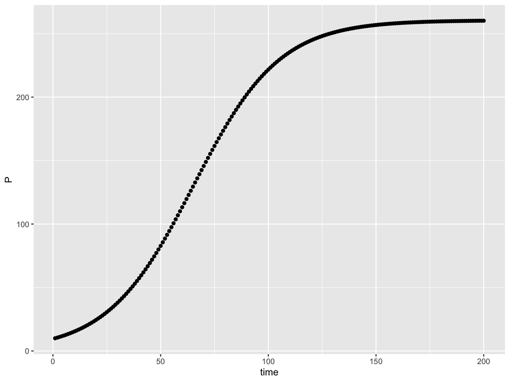

```r
colnames(result)=c("time","P")
# turn it into a data frame
result = as.data.frame(result)
ggplot(result, aes(time, P))+geom_point()
```

```r
# extra our metrics of interest  from this
# maximum population it gets to
maxpop = max(result$P)
maxpop
```

```
## [1] 260.1915
```

```r
# years required to get to a threshold population (150)
# which will tell when this occurs - we will take the first one
thresh = 150
idx = which(result$P > thresh)[1]

# if it never gets there
idx = ifelse(is.na(idx), length(result$P), idx)
# turn this index into a year (might be the same if time step in 1 but just in case it isn't)
threshyear = result$time[idx]
threshyear
```

```
## [1] 72
```

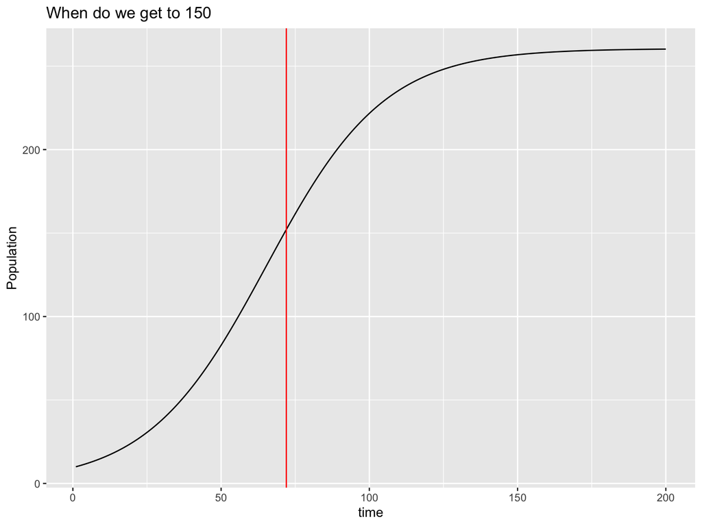

```r
ggplot(result, aes(time, P))+geom_line()+geom_vline(xintercept=threshyear, col="red")+labs(y="Population",title="When do we get to 150")
```

```r
# or how about threshold of 50% of carrying capacity
thresh = 0.5*sens_P$X[1,"K"]
idx = which(result$P > thresh)[1]

# if it never gets there
idx = ifelse(is.na(idx), length(result$P), idx)
# turn this index into a year (might be the same if time step in 1 but just in case it isn't)
threshyear = result$time[idx]
threshyear
```

```
## [1] 66
```

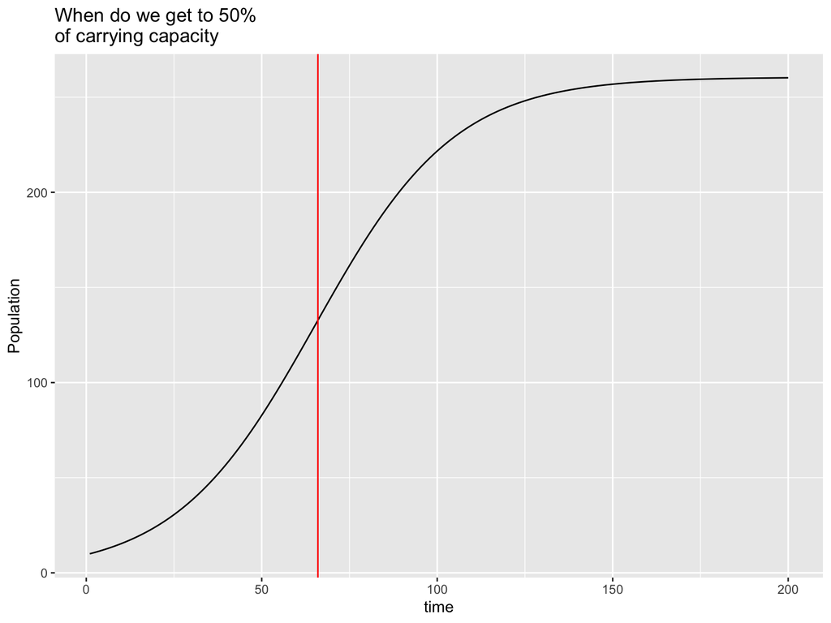

```r
ggplot(result, aes(time, P))+geom_line()+geom_vline(xintercept=threshyear, col="red")+labs(y="Population",title="When do we get to 50%\nof carrying capacity")
```

# Make a different metric or ODE

- try a metric that gives you the population at year 5
- change the way carrying capacity is used

# Try it running ODE for *all* parameters

One issue is the volume of output! you have a time series for *each* parameter set

So just save metrics

Lets create two additional functions that will help us

- a function that computes the metrics we want
- a function that runs our ode solver and computes the metrics (I call it a **wrapper** function as it is really just a workflow/wrapper to call ode solver and then compute metrics)
- wrapper takes as input
  - parameters
  - initial conditions
  - simulation time
  - ode (function name)
  - how to compute metrics (function name)
- always test to make sure it works (good coding practice)

```r
# turn computing our metrics into a function

compute_metrics = function(result, thresh) {
  maxpop = max(result$P)
idx = which(result$P > thresh)[1]
idx = ifelse(is.na(idx), length(result$P), idx)
threshyear = result$time[idx]
return(list(maxpop=maxpop, threshyear=threshyear))}

# try it on our first parameter set, and look at when it gets to 100
compute_metrics(result, 100)
```

```
## $maxpop
## [1] 260.1915
##
## $threshyear
## [1] 56
```

```r
# great but we need to apply the ode and this function for all of our parameters



# define a wrapper function to do everything we need - run solver and compute metrics - and send back results for each parameter

# lets make the threshold 90% of carrying capacity

p_wrapper = function(r,K, Pinitial, simtimes, odefunc, metricfunc) {
    parms = list(r=r, K=K)
    result = ode(y=Pinitial, times=simtimes, func=odefunc, parms=parms)
    colnames(result)=c("time","P")
  # get metrics
  metrics=metricfunc(as.data.frame(result), thresh=100)
  return(metrics)
}

# test
p_wrapper(r=0.01, K=150, Pinitial=3, simtimes=seq(from=1,to=10),
         odefunc=dpopgrowth, metricfunc=compute_metrics)
```

```
## $maxpop
## [1] 3.276352
##
## $threshyear
## [1] 10
```

# Next step

Run the wrapper for all parameters and look at results

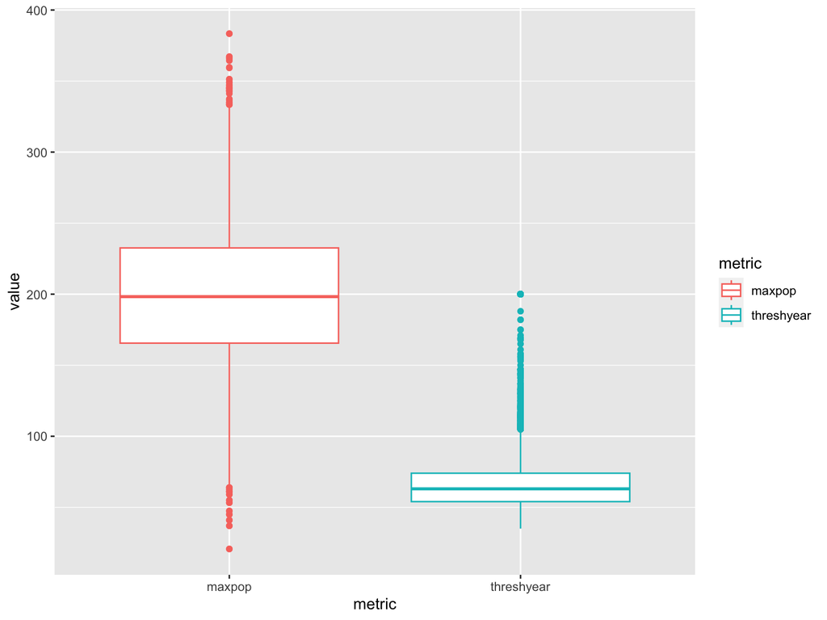

```r
# now use pmap as we did before

allresults = as.data.frame(sens_P$X) %>% pmap(p_wrapper, Pinitial=Pinitial, simtimes=simtimes, odefunc=dpopgrowth, metricfunc=compute_metrics)

# extract out results from pmap into a data frame
allres = allresults %>% map_dfr(`[`,c("maxpop","threshyear"))


# create boxplots
tmp = allres %>% pivot_longer(cols=everything(),names_to="metric", values_to="value")
ggplot(tmp, aes(metric, value, col=metric))+geom_boxplot()
```

# Compute the sobol indicies for each metric

- save the *tell* to different objects so you can keep re-using the original sobel object
- look at total effect and first order sensitivity

```r
# sobol can only handle one output at a time  - so we will need to do them separately

sens_P_maxpop = sensitivity::tell(sens_P,allres$maxpop)

# first-order indices (main effect without co-variance)
rownames(sens_P_maxpop$S)=c("r","K")
sens_P_maxpop$S
```

```
##      original          bias  std. error  min. c.i.   max. c.i.
## r -0.03348807  7.119857e-04 0.022703711 -0.0760784 0.006275991
## K  0.99089239 -7.251291e-05 0.002274313  0.9872587 0.995669666
```

```r
# total sensitivity index -note that this partitions the output variance
rownames(sens_P_maxpop$T)=c("r","K")
sens_P_maxpop$T
```

```
##      original          bias std. error   min. c.i.   max. c.i.
## r 0.007414572  6.595647e-05 0.00132905 0.004426511 0.009722968
## K 1.037331096 -8.319625e-04 0.02264226 0.994436417 1.080286422
```

```r
# create another one for max year
sens_P_threshyear = sensitivity::tell(sens_P,allres$threshyear)
# first-order indices (main effect without co-variance)
rownames(sens_P_threshyear$S)=c("r","K")
sens_P_threshyear$S
```

```
##    original         bias std. error min. c.i. max. c.i.
## r 0.3191306  0.002302734 0.03457022 0.2557997 0.3930210
## K 0.7002164 -0.003989074 0.02920943 0.6501273 0.7622566
```

```r
# total sensitivity index -note that this partitions the output variance - so values sum to 1
rownames(sens_P_threshyear$T)=c("r","K")
sens_P_threshyear$T
```

```
##    original         bias std. error min. c.i. max. c.i.
## r 0.3383952  0.002728221 0.03403247 0.2576101 0.3977763
## K 0.7010013 -0.002298252 0.03237119 0.6367773 0.7633586
```

# Negative sobol first order indices

if confidence interval includes zero - not a problem

if it doesn’t there are numerical issues - try running more samples

# Error messages from ODE

*In lsoda(y, times, func, parms, …) : an excessive amount of work (> maxsteps ) was done, but integration was not successful - increase maxsteps*

Suggest that the solver (numerical integration) had issues

- increasing maxsteps can help

  ```
  *result = ode(y=Pinitial, times=simtimes, func=func, parms=parms, maxsteps=100000) *
  ```

- trying different methods

  ```
  *result = ode(y=Pinitial, times=simtimes, func=func, parms=parms, method="daspk")*
  ```

- “stiff” problems are harder for numerical integration to solve - (small changes have big impacts); a threshold carrying capacity does that

# Assignment

here

Want to go further?….

Try using Sobol for the diffusion model - what would be your metric?